# Lecture 8: Asymptotic theory

Economics 527: Econometric Methods

Author

Vadim Marmer, UBC

# Convergence in probability

## OLS as a function of sample averages

- Model and OLS estimator:
  $$Y_i = X_i^\top \beta + U_i, \qquad \hat\beta = \Big(\sum_{i=1}^n X_i X_i^\top\Big)^{-1} \sum_{i=1}^n X_i Y_i$$
- Normal errors, exact distribution given the regressors:
  $$\begin{aligned}
  & U_i \mid X_i \sim N(0, \sigma^2) \\
  \Longrightarrow\quad & \hat\beta \mid X_1, \ldots, X_n \sim N\Big(\beta,\ \sigma^2 \Big(\sum_{i=1}^n X_i X_i^\top\Big)^{-1}\Big)
  \end{aligned}$$
- Without normality, write OLS in terms of sample averages:
  $$\hat\beta = \Big({\color{red}\frac{1}{n}} \sum_{i=1}^n X_i X_i^\top\Big)^{-1} {\color{red}\frac{1}{n}} \sum_{i=1}^n X_i Y_i$$
- Use approximations; all limits below are as $n \to \infty$.

## Limit of a non-random sequence

- Non-random sequence:
  $$\{\underset{1\times1}{a_n} \in \mathbb{R} : n \ge 1\}$$
- **Definition.** $a_n$ converges to $a$, $a_n \to a$, $a = \lim a_n$, if for all $\varepsilon > 0$ there is $N_\varepsilon \in \mathbb{N}$:
  $$|a_n - a| < \varepsilon \quad \text{for all } n \ge N_\varepsilon$$
- $a$: good approximation of $a_n$ for all $n \ge N_\varepsilon$.
- Sequence $a_n$ with bands $a \pm \varepsilon$ and $a \pm \varepsilon'$, $\varepsilon' < \varepsilon$:

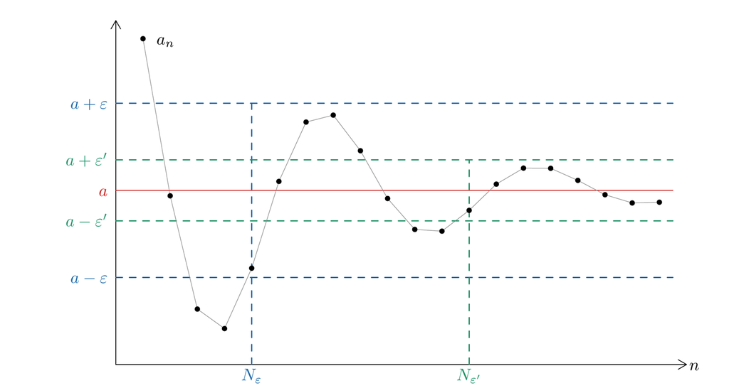

## Estimator as a random sequence

- $\hat\theta_n$: estimator of $\theta$ from $n$ observations; random sequence:
  $$\{\underset{1\times1}{\hat\theta_n} : n \ge 1\}, \qquad \hat\theta_n = \hat\theta_n(\omega), \quad \omega \in \Omega$$
- OLS from $n$ observations: $\hat\beta_n = \hat\beta_n(\omega)$, random.
- Non-random sequences from $\hat\theta_n$; apply the definition of a limit to them:
  $$\begin{aligned}
  \text{Moments, } r > 0 &: \quad a_n = \mathrm{E}\left[|\hat\theta_n - \theta|^r\right] \\
  \text{Probabilities, } \delta > 0 &: \quad a_n = \mathrm{P}\big(|\hat\theta_n - \theta| > \delta\big)
  \end{aligned}$$

## Convergence in $r$-th mean

- **Definition.** $\hat\theta_n$ converges to $\theta$ in $r$-th mean, $r > 0$, if:
  $$\mathrm{E}\left[|\hat\theta_n - \theta|^r\right] \to 0$$
- $a_n = \mathrm{E}\left[|\hat\theta_n - \theta|^r\right] \to 0$: for all $\varepsilon > 0$ there is $N_\varepsilon \in \mathbb{N}$:
  $$\mathrm{E}\left[|\hat\theta_n - \theta|^r\right] < \varepsilon \quad \text{for all } n \ge N_\varepsilon$$
- $r = 2$, mean squared error (MSE):
  $$\mathrm{E}\left[(\hat\theta_n - \theta)^2\right]$$

## Definition of convergence in probability

- Non-random sequence, $\delta > 0$ fixed:
  $$a_n = \mathrm{P}\big(|\hat\theta_n - \theta| > \delta\big), \qquad n \ge 1$$
- **Definition.** $\hat\theta_n$ converges in probability to $\theta$, $\hat\theta_n \to_p \theta$, if for all $\delta > 0$:
  $$\mathrm{P}\big(|\hat\theta_n - \theta| > \delta\big) \to 0$$
- Equivalently, for all $\delta > 0$:
  $$\begin{aligned}
  \mathrm{P}\big(|\hat\theta_n - \theta| \le \delta\big) &= 1 - \underbrace{\mathrm{P}\big(|\hat\theta_n - \theta| > \delta\big)}_{\to\,0} \\
  &\to 1
  \end{aligned}$$

## Densities of $\hat\theta_n$ as $n$ grows

- Example: densities for $\hat\theta_n \sim N(\theta, 1/n)$.
- Shaded: $\mathrm{P}(|\hat\theta_n - \theta| > \delta)$.

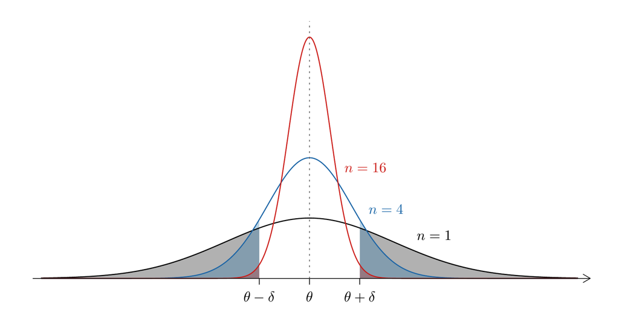

- $\hat\theta_n \to_p \theta$: distribution of $\hat\theta_n$ more concentrated around $\theta$.

## Markov’s inequality

- Markov’s inequality connects tail probabilities to expectations; the core device for establishing convergence in probability.
- **Theorem.** $X$: random variable, $M > 0$:
  $$\mathrm{P}\big(|X| \ge M\big) \le \frac{\mathrm{E}\left[|X|\right]}{M}$$
- Expectation of an indicator, $X$ with density $f_X$, split at $-M$ and $M$:
  $$\begin{aligned}
  \mathrm{E}\left[\mathbf{1}(|X| \ge M)\right] &= \int_{-\infty}^{\infty} \mathbf{1}(|x| \ge M)\, f_X(x)\, dx \\
  &= \int_{-\infty}^{-M} \underbrace{\mathbf{1}(|x| \ge M)}_{=\,1} f_X(x)\, dx \\
  &\qquad + \overbrace{\int_{-M}^{M} \underbrace{\mathbf{1}(|x| \ge M)}_{=\,0 \text{ for } |x| < M} f_X(x)\, dx}^{=\,0} \\
  &\qquad + \int_{M}^{\infty} \underbrace{\mathbf{1}(|x| \ge M)}_{=\,1} f_X(x)\, dx \\
  &= \int_{-\infty}^{-M} f_X(x)\, dx + \int_{M}^{\infty} f_X(x)\, dx \\
  &= \mathrm{P}(X \le -M) + \mathrm{P}(X \ge M) \\
  &= \mathrm{P}\big(|X| \ge M\big)
  \end{aligned}$$
- Split $1$ into two indicators:
  $$1 = \mathbf{1}(|X| \ge M) + \mathbf{1}(|X| < M)$$
- Expectation of $|X|$:
  $$\begin{aligned}
  \mathrm{E}\left[|X|\right] &= \mathrm{E}\left[|X| \cdot 1\right] \\
  &= \mathrm{E}\left[|X|\, \big(\mathbf{1}(|X| \ge M) + \mathbf{1}(|X| < M)\big)\right] \\
  &= \mathrm{E}\left[|X|\, \mathbf{1}(|X| \ge M)\right] + \underbrace{\mathrm{E}\left[|X|\, \mathbf{1}(|X| < M)\right]}_{\ge\,0} \\
  &\ge \mathrm{E}\left[|X|\, \mathbf{1}(|X| \ge M)\right] \\
  &\ge \mathrm{E}\left[M\, \mathbf{1}(|X| \ge M)\right] \quad \substack{|X| \ge M \\ \text{where } \mathbf{1}(|X| \ge M) = 1} \\
  &= M\, \mathrm{E}\left[\mathbf{1}(|X| \ge M)\right] \\
  &= M\, \mathrm{P}\big(|X| \ge M\big)
  \end{aligned}$$
- Divide by $M$:
  $$\boxed{\ \mathrm{P}\big(|X| \ge M\big) \le \frac{\mathrm{E}\left[|X|\right]}{M}\ }$$

## Convergence in $r$-th mean and in probability

- **Claim.**
  $$\mathrm{E}\left[|\hat\theta_n - \theta|^r\right] \to 0 \ \text{ for some } r > 0 \quad \Longrightarrow \quad \hat\theta_n \to_p \theta$$
- Markov’s inequality, for all $\delta > 0$:
  $$\begin{aligned}
  \mathrm{P}\big(|\hat\theta_n - \theta| > \delta\big) &= \mathrm{P}\big(|\hat\theta_n - \theta|^r > \delta^r\big) \\
  &\le \mathrm{P}\big(\underbrace{|\hat\theta_n - \theta|^r}_{X} \ge \underbrace{\delta^r}_{M}\big) \\
  &\le \frac{1}{\delta^r}\, \underbrace{\mathrm{E}\left[|\hat\theta_n - \theta|^r\right]}_{\to\,0} \\
  &\to 0
  \end{aligned}$$
- Therefore:
  $$\boxed{\ \hat\theta_n \to_p \theta\ }$$

## Chebyshev’s inequality

- As on the previous slide, $r = 2$, $Y - \mathrm{E}\left[Y\right]$ in place of $\hat\theta_n - \theta$, $\delta > 0$:
  $$\begin{aligned}
  \mathrm{P}\big(|Y - \mathrm{E}\left[Y\right]| > \delta\big) &\le \frac{1}{\delta^2}\, \mathrm{E}\left[|Y - \mathrm{E}\left[Y\right]|^2\right] \\
  &= \frac{1}{\delta^2}\, \mathrm{Var}\left(Y\right)
  \end{aligned}$$

## Bias and variance tending to zero

- **Claim.** For an estimator $\hat\theta_n$ of $\theta$:
  $$\begin{aligned}
  & \text{1. } \mathrm{E}\left[\hat\theta_n\right] \to \theta \\
  & \text{2. } \mathrm{Var}\left(\hat\theta_n\right) \to 0 \\
  \Longrightarrow\quad & \hat\theta_n \to_p \theta
  \end{aligned}$$
- Recall:
  $$\underbrace{\mathrm{E}\left[(\hat\theta_n - \theta)^2\right]}_{\text{MSE}} = \mathrm{Var}\left(\hat\theta_n\right) + \underbrace{\big(\mathrm{E}\left[\hat\theta_n\right] - \theta\big)^2}_{\text{Bias}^2}$$
- Markov with $r = 2$, for all $\delta > 0$:
  $$\begin{aligned}
  \mathrm{P}\big(|\hat\theta_n - \theta| > \delta\big) &\le \frac{1}{\delta^2}\, \mathrm{E}\left[(\hat\theta_n - \theta)^2\right] \\
  &= \frac{1}{\delta^2} \Big(\underbrace{\mathrm{Var}\left(\hat\theta_n\right)}_{\to\,0 \text{ by 2.}} + \big(\underbrace{\mathrm{E}\left[\hat\theta_n\right] - \theta}_{\to\,0 \text{ by 1.}}\big)^2\Big) \\
  &\to 0
  \end{aligned}$$
- Therefore:
  $$\boxed{\ \hat\theta_n \to_p \theta\ }$$

# Law of large numbers (LLN)

## LLN for uncorrelated observations

- **Theorem.** $X_1, \ldots, X_n$: random variables; for all $i$ and all $j \ne i$:
  $$\begin{aligned}
  & \mathrm{E}\left[X_i\right] = \mu, \qquad \mathrm{Var}\left(X_i\right) = \sigma^2 < \infty, \qquad \mathrm{Cov}\left(X_i, X_j\right) = 0 \\
  \Longrightarrow\quad & \bar X_n = \frac{1}{n} \sum_{i=1}^n X_i \to_p \mu
  \end{aligned}$$

## Proof of the LLN, step 1: mean and variance

- $\mathrm{E}\left[\bar X_n\right] = \mu$, so bias is zero:
  $$\begin{aligned}
  \mathrm{E}\left[\bar X_n\right] &= \frac{1}{n} \sum_{i=1}^n \mathrm{E}\left[X_i\right] \\
  &= \mu
  \end{aligned}$$
- Variance of $\bar X_n$:
  $$\begin{aligned}
  \mathrm{Var}\left(\bar X_n\right) &= \mathrm{Var}\left(\frac{1}{n} \sum_{i=1}^n X_i\right) \\
  &= \frac{1}{n^2}\, \mathrm{Var}\left(\sum_{i=1}^n X_i\right) \\
  &= \frac{1}{n^2} \sum_{i=1}^n \sum_{j=1}^n \mathrm{Cov}\left(X_i, X_j\right) \\
  &= \frac{1}{n^2} \Big(\sum_{i=1}^n \mathrm{Var}\left(X_i\right) + \underbrace{\sum_{i=1}^n \sum_{j \ne i} \mathrm{Cov}\left(X_i, X_j\right)}_{=\,0}\Big) \\
  &= \frac{1}{n^2} \sum_{i=1}^n \underbrace{\mathrm{Var}\left(X_i\right)}_{=\,\sigma^2} \\
  &= \frac{1}{n^2}\, (\sigma^2 \cdot n) \\
  &= \frac{\sigma^2}{n} \\
  &\to 0
  \end{aligned}$$

## Proof of the LLN, step 2: Chebyshev’s inequality

- Chebyshev with $\mathrm{E}\left[\bar X_n\right] = \mu$, for all $\delta > 0$:
  $$\begin{aligned}
  \mathrm{P}\big(|\bar X_n - \mu| > \delta\big) &\le \frac{1}{\delta^2}\, \mathrm{Var}\left(\bar X_n - \mu\right) \\
  &= \frac{1}{\delta^2}\, \mathrm{Var}\left(\bar X_n\right) \\
  &= \frac{1}{\delta^2}\, \frac{\sigma^2}{n} \\
  &\to 0
  \end{aligned}$$
- Therefore:
  $$\boxed{\ \bar X_n \to_p \mu = \mathrm{E}\left[X_i\right]\ }$$

## Extension to different means

- $\mathrm{E}\left[X_i\right] = \mu_i$, not constant; $\mathrm{Var}\left(X_i\right) = \sigma^2 < \infty$; $\mathrm{Cov}\left(X_i, X_j\right) = 0$ for $i \ne j$.
- Centre each $X_i$ at its mean:
  $$\begin{aligned}
  & Y_i = X_i - \mathrm{E}\left[X_i\right] \\
  \Longrightarrow\quad & \mathrm{E}\left[Y_i\right] = 0, \qquad \mathrm{Var}\left(Y_i\right) = \sigma^2, \qquad \mathrm{Cov}\left(Y_i, Y_j\right) = 0 \ \text{ for } i \ne j
  \end{aligned}$$
- LLN for $Y_1, \ldots, Y_n$:
  $$\begin{aligned}
  \frac{1}{n} \sum_{i=1}^n X_i - \frac{1}{n} \sum_{i=1}^n \mathrm{E}\left[X_i\right] &= \frac{1}{n} \sum_{i=1}^n \big(X_i - \mathrm{E}\left[X_i\right]\big) \\
  &= \frac{1}{n} \sum_{i=1}^n Y_i \\
  &\to_p 0
  \end{aligned}$$

## Extension to different variances

- $Y_1, \ldots, Y_n$: random variables; for all $i$ and all $j \ne i$:
  $$\begin{aligned}
  & \mathrm{E}\left[Y_i\right] = 0, \qquad \mathrm{Var}\left(Y_i\right) = \mathrm{E}\left[Y_i^2\right] = \sigma_i^2 \ \text{ not constant} \\
  & \mathrm{Cov}\left(Y_i, Y_j\right) = 0
  \end{aligned}$$
- Bounded variances, $\bar\sigma^2$ not depending on $n$:
  $$\sigma_i^2 \le \max_{j = 1, \ldots, n} \sigma_j^2 \le \bar\sigma^2$$
- Variance of the average $\to 0$ $\Longrightarrow$ $\frac{1}{n} \sum_{i=1}^n Y_i \to_p 0$, by Chebyshev:
  $$\begin{aligned}
  \mathrm{Var}\left(\frac{1}{n} \sum_{i=1}^n Y_i\right) &= \frac{1}{n^2}\, \mathrm{Var}\left(\sum_{i=1}^n Y_i\right) \\
  &= \frac{1}{n^2} \sum_{i=1}^n \mathrm{Var}\left(Y_i\right) \\
  &= \frac{1}{n^2} \sum_{i=1}^n \sigma_i^2 \\
  &\le \frac{1}{n^2}\, n \bar\sigma^2 \\
  &= \frac{\bar\sigma^2}{n} \\
  &\to 0
  \end{aligned}$$

## Extension to dependent observations

- Variance of the average, non-zero covariances:
  $$\begin{aligned}
  \mathrm{Var}\left(\frac{1}{n} \sum_{i=1}^n Y_i\right) &= \frac{1}{n^2} \sum_{i=1}^n \sum_{j=1}^n \mathrm{Cov}\left(Y_i, Y_j\right) \\
  &= \frac{1}{n^2} \sum_{i=1}^n \mathrm{Var}\left(Y_i\right) + \frac{1}{n^2} \sum_{i=1}^n \sum_{j \ne i} \mathrm{Cov}\left(Y_i, Y_j\right) \\
  &= \frac{1}{n^2} \sum_{i=1}^n \mathrm{Var}\left(Y_i\right) + 2\, \frac{1}{n^2} \sum_{i=1}^{n-1} \sum_{j=i+1}^n \mathrm{Cov}\left(Y_i, Y_j\right)
  \end{aligned}$$
- Number of distinct covariances, order $n^2$:
  $$\frac{n^2 - n}{2} = \frac{n(n-1)}{2}$$
- Triangle inequality, $|a + b| \le |a| + |b|$:
  $$\begin{aligned}
  \Big|\frac{1}{n^2} \sum_{i=1}^n \sum_{j \ne i} \mathrm{Cov}\left(Y_i, Y_j\right)\Big| &\le \frac{1}{n^2} \underbrace{\sum_{i=1}^n \sum_{j \ne i} \big|\mathrm{Cov}\left(Y_i, Y_j\right)\big|}_{\text{if of smaller order than } n^2} \\
  &\to 0
  \end{aligned}$$
- Double sum smaller order than $n^2$: for example, each observation correlated with only a fixed number of others, with bounded covariances.

## Example: $Y_i = \varepsilon_i + \varepsilon_{i+1}$

- $\varepsilon_1, \varepsilon_2, \ldots$: iid (independent and identically distributed), $0 < \mathrm{Var}\left(\varepsilon_i\right) < \infty$.
- Neighbours share one $\varepsilon$:
  $$\begin{aligned}
  Y_i &= \varepsilon_i + \varepsilon_{i+1} \\
  Y_{i+1} &= \varepsilon_{i+1} + \varepsilon_{i+2} \\
  Y_{i+2} &= \varepsilon_{i+2} + \varepsilon_{i+3}
  \end{aligned}$$
- Covariances of $Y_i$ and $Y_{i+h}$:
  $$\mathrm{Cov}\left(Y_i, Y_{i+1}\right) \ne 0, \qquad \mathrm{Cov}\left(Y_i, Y_{i+h}\right) = 0 \quad \text{for } h \ge 2$$

## Weak LLN for iid observations

- Independence instead of uncorrelatedness: finite variance not required.
- **Theorem.** $X_1, \ldots, X_n$: iid random variables:
  $$\begin{aligned}
  & \mathrm{E}\left[|X_1|\right] < \infty \\
  \Longrightarrow\quad & \bar X_n = \frac{1}{n} \sum_{i=1}^n X_i \to_p \mathrm{E}\left[X_1\right] \\
  & \mathrm{E}\left[X_1\right] = \int_{-\infty}^{\infty} x\, f_X(x)\, dx \quad \text{with density } f_X
  \end{aligned}$$
- Stated without proof; this is the LLN we will use.

# Vectors and Slutsky’s theorem

## Convergence in probability of a random vector

- Estimator $\hat\theta_n$ and parameter $\theta$, $k \times 1$:
  $$\hat\theta_n = \begin{pmatrix} \hat\theta_{n,1} \\ \vdots \\ \hat\theta_{n,k} \end{pmatrix}, \qquad \theta = \begin{pmatrix} \theta_1 \\ \vdots \\ \theta_k \end{pmatrix}$$
- **Definition.** $\hat\theta_n$ converges in probability to $\theta$, $\hat\theta_n \to_p \theta$, two versions:
  $$\begin{aligned}
  \text{1. Element by element:} \quad & \hat\theta_{n,j} \to_p \theta_j \quad \text{for all } j = 1, \ldots, k \\
  \text{2. In norm:} \quad & \|\hat\theta_n - \theta\| \to_p 0, \qquad \|x\| = \sqrt{x_1^2 + \cdots + x_k^2}
  \end{aligned}$$
- **Claim.** 1 $\Longleftrightarrow$ 2.
  $$\|\hat\theta_n - \theta\|^2 = (\hat\theta_{n,1} - \theta_1)^2 + \cdots + (\hat\theta_{n,k} - \theta_k)^2$$
- 1 $\Longrightarrow$ 2: each element converges to zero, so the finite sum converges to zero.
- 2 $\Longrightarrow$ 1: non-negative summands; the sum converges to zero only if each summand does.

## Sum of two sequences

- **Claim.** For $1 \times 1$ sequences $\hat\theta_{n,1}$ and $\hat\theta_{n,2}$:
  $$\begin{aligned}
  & \hat\theta_{n,1} \to_p \theta_1, \quad \hat\theta_{n,2} \to_p \theta_2 \\
  \Longrightarrow\quad & \hat\theta_{n,1} + \hat\theta_{n,2} \to_p \theta_1 + \theta_2
  \end{aligned}$$
- Triangle inequality, then a union bound, for all $\delta > 0$:
  $$\begin{aligned}
  & \mathrm{P}\big(|\hat\theta_{n,1} + \hat\theta_{n,2} - (\theta_1 + \theta_2)| > \delta\big) \\
  &\le \mathrm{P}\big(|\hat\theta_{n,1} - \theta_1| + |\hat\theta_{n,2} - \theta_2| > \delta\big) \\
  &\le \mathrm{P}\Big(|\hat\theta_{n,1} - \theta_1| > \frac{\delta}{2} \ \text{ or } \ |\hat\theta_{n,2} - \theta_2| > \frac{\delta}{2}\Big) \\
  &\le \mathrm{P}\Big(|\hat\theta_{n,1} - \theta_1| > \frac{\delta}{2}\Big) + \mathrm{P}\Big(|\hat\theta_{n,2} - \theta_2| > \frac{\delta}{2}\Big) \\
  &\to 0
  \end{aligned}$$
- Therefore:
  $$\boxed{\ \hat\theta_{n,1} + \hat\theta_{n,2} \to_p \theta_1 + \theta_2\ }$$

## Slutsky’s theorem

- More general than sums: convergence is preserved by continuous functions.
- **Theorem.** $\hat\theta_n$: $k \times 1$; $\theta \in \mathbb{R}^k$ non-random; $h : \mathbb{R}^k \to \mathbb{R}^m$ continuous at $\theta$; $\to_p$ in norm:
  $$\hat\theta_n \to_p \theta \quad \Longrightarrow \quad h(\hat\theta_n) \to_p h(\theta)$$
- $h$ continuous at $\theta$: for all $\delta > 0$ there is $\eta_\delta > 0$:
  $$\|\hat\theta_n - \theta\| \le \eta_\delta \quad \Longrightarrow \quad \|h(\hat\theta_n) - h(\theta)\| \le \delta$$
- Inclusion of events, then probabilities, for all $\delta > 0$:
  $$\begin{aligned}
  & \big\{\|\hat\theta_n - \theta\| \le \eta_\delta\big\} \subset \big\{\|h(\hat\theta_n) - h(\theta)\| \le \delta\big\} \\
  \Longrightarrow\quad & \underbrace{\mathrm{P}\big(\|\hat\theta_n - \theta\| \le \eta_\delta\big)}_{\to\,1 \text{ (in norm)}} \le \mathrm{P}\big(\|h(\hat\theta_n) - h(\theta)\| \le \delta\big) \le 1 \\
  \Longrightarrow\quad & \mathrm{P}\big(\|h(\hat\theta_n) - h(\theta)\| \le \delta\big) \to 1 \\
  \Longrightarrow\quad & \boxed{\ h(\hat\theta_n) \to_p h(\theta)\ }
  \end{aligned}$$

## Examples: product, ratio

- $\hat\theta_{n,1} \to_p \theta_1$, $\hat\theta_{n,2} \to_p \theta_2$; element by element $\Longrightarrow$ in norm; Slutsky for product and ratio:
  $$\begin{aligned}
  \hat\theta_{n,1}\, \hat\theta_{n,2} &\to_p \theta_1\, \theta_2 \\
  \frac{\hat\theta_{n,1}}{\hat\theta_{n,2}} &\to_p \frac{\theta_1}{\theta_2} \quad \text{if } \theta_2 \ne 0
  \end{aligned}$$
- $h(\theta_1, \theta_2) = \theta_1 / \theta_2$: not continuous at $\theta_2 = 0$.
- $X_1, \ldots, X_n$ iid, $\mathrm{E}\left[|X_1|\right] < \infty$; weak LLN, then Slutsky for $h(u) = u^2$ and $h(u) = 1/u$:
  $$\begin{aligned}
  (\bar X_n)^2 &\to_p \big(\mathrm{E}\left[X_1\right]\big)^2 \\
  \frac{1}{\bar X_n} &\to_p \frac{1}{\mathrm{E}\left[X_1\right]} \quad \text{if } \mathrm{E}\left[X_1\right] \ne 0
  \end{aligned}$$

## Example: inverse of a matrix

- $X_i$: $k \times 1$, iid, $\mathrm{E}\left[X_i X_i^\top\right]$ finite; weak LLN, element by element:
  $$\frac{1}{n} \sum_{i=1}^n X_i X_i^\top \to_p \mathrm{E}\left[X_i X_i^\top\right]$$
- $\mathrm{E}\left[X_i X_i^\top\right]$: symmetric, p.s.d.
- Assume $\mathrm{E}\left[X_i X_i^\top\right]$ p.d.; $h(\cdot) = (\cdot)^{-1}$: continuous at a p.d. matrix.
- Element by element $\Longrightarrow$ in norm, then Slutsky on the $k^2$ elements:
  $$\Big(\frac{1}{n} \sum_{i=1}^n X_i X_i^\top\Big)^{-1} \to_p \big(\mathrm{E}\left[X_i X_i^\top\right]\big)^{-1}$$

# Convergence in distribution

## Normal distributions and $\Phi$

- Standard normal CDF:
  $$\Phi(t) = \mathrm{P}(Z \le t), \qquad Z \sim N(0, 1)$$
- For $X \sim N(\mu, \sigma^2)$, $\sigma > 0$:
  $$\begin{aligned}
  \mathrm{P}(X \le t) &= \mathrm{P}(X - \mu \le t - \mu) \\
  &= \mathrm{P}\Big(\underbrace{\frac{X - \mu}{\sigma}}_{=\,Z \sim N(0,1)} \le \frac{t - \mu}{\sigma}\Big) \\
  &= \Phi\Big(\frac{t - \mu}{\sigma}\Big)
  \end{aligned}$$
- For any $X$, $\mu \in \mathbb{R}$ and $\sigma > 0$:
  $$\mathrm{P}(X \le t) = \Phi\Big(\frac{t - \mu}{\sigma}\Big) \ \text{ for all } t \in \mathbb{R} \quad \Longleftrightarrow \quad X \sim N(\mu, \sigma^2)$$

## Asymptotic normality

- $\hat\theta_n$, $\theta$: $1 \times 1$.
- **Definition.** $\hat\theta_n$ asymptotically normal: for some $\omega > 0$:
  $$\begin{aligned}
  \mathrm{P}\big(\sqrt{n}(\hat\theta_n - \theta) \le t\big) &= {\color{red}\mathrm{P}\Big(\frac{\sqrt{n}(\hat\theta_n - \theta)}{\omega} \le \frac{t}{\omega}\Big)} \\
  &\to {\color{red}\Phi\Big(\frac{t}{\omega}\Big)} \quad \text{for all } t \in \mathbb{R} \\
  \Longleftrightarrow\quad \frac{\sqrt{n}(\hat\theta_n - \theta)}{\omega} &\to_d N(0, 1) \\
  \Longleftrightarrow\quad \sqrt{n}(\hat\theta_n - \theta) &\to_d N(0, \omega^2)
  \end{aligned}$$
- Convergence in distribution concerns distribution functions, not convergence of the random variables themselves.
- Approximate using the normal CDF; valid as $n \to \infty$:
  $$\mathrm{P}\big(\sqrt{n}(\hat\theta_n - \theta) \le t\big) \approx \Phi\Big(\frac{t}{\omega}\Big)$$

## Why $\sqrt{n}$

- $X_1, \ldots, X_n$ iid, mean $\theta$, variance $0 < \sigma^2 < \infty$; $\hat\theta_n = \bar X_n$:
  $$\hat\theta_n - \theta \to_p 0 \quad \text{(LLN)}$$
- Variance of $\hat\theta_n - \theta$ (proof of the LLN, step 1):
  $$\begin{aligned}
  \mathrm{Var}\left(\hat\theta_n - \theta\right) &= \mathrm{Var}\left(\bar X_n\right) \\
  &= \frac{\sigma^2}{n} \\
  &\to 0
  \end{aligned}$$
- Scaled by $\sqrt{n}$:
  $$\begin{aligned}
  \mathrm{Var}\left(\sqrt{n}(\hat\theta_n - \theta)\right) &= n\, \mathrm{Var}\left(\hat\theta_n - \theta\right) \\
  &= n \cdot \frac{\sigma^2}{n} \\
  &= \sigma^2
  \end{aligned}$$
- Scaled by $n^\alpha$:
  $$\begin{aligned}
  \mathrm{Var}\left(n^\alpha(\hat\theta_n - \theta)\right) &= \frac{n^{2\alpha}}{n}\, \sigma^2 \\
  &= n^{2\alpha - 1} \sigma^2 \\
  &\to \begin{cases} \infty & \text{if } \alpha > \tfrac12 \\ \sigma^2 & \text{if } \alpha = \tfrac12 \\ 0 & \text{if } \alpha < \tfrac12 \end{cases}
  \end{aligned}$$

# Central limit theorem (CLT)

## Univariate CLT

- **Theorem.** $X_1, \ldots, X_n$: iid random variables:
  $$\begin{aligned}
  & \mathrm{E}\left[X_i\right] = 0, \qquad \mathrm{Var}\left(X_i\right) = \mathrm{E}\left[X_i^2\right] = \sigma^2, \quad 0 < \sigma^2 < \infty \\
  \Longrightarrow\quad & \frac{1}{\sqrt{n}} \sum_{i=1}^n X_i \to_d N(0, \sigma^2)
  \end{aligned}$$
- CDF form, for all $t \in \mathbb{R}$:
  $$\mathrm{P}\Big(\frac{1}{\sqrt{n}} \sum_{i=1}^n X_i \le t\Big) \to \Phi\Big(\frac{t}{\sigma}\Big)$$
- In terms of $\bar X_n$:
  $$\sqrt{n}\, \bar X_n = \frac{1}{\sqrt{n}} \sum_{i=1}^n X_i \to_d N(0, \sigma^2)$$

## Non-zero mean

- $X_1, \ldots, X_n$ iid, $\mathrm{E}\left[X_i\right] = \mu \ne 0$, $\mathrm{Var}\left(X_i\right) = \sigma^2$, $0 < \sigma^2 < \infty$:
  $$\frac{1}{\sqrt{n}} \sum_{i=1}^n X_i \nrightarrow_d N(\mu, \sigma^2)$$
- Add and subtract $\mu$:
  $$\begin{aligned}
  \frac{1}{\sqrt{n}} \sum_{i=1}^n X_i &= \frac{1}{\sqrt{n}} \sum_{i=1}^n (X_i - \mu) + \frac{1}{\sqrt{n}}\, n\mu \\
  &= \underbrace{\frac{1}{\sqrt{n}} \sum_{i=1}^n \underbrace{(X_i - \mu)}_{\mathrm{E}\left[X_i - \mu\right] \,=\, 0}}_{\to_d\, N(0, \sigma^2)} + \underbrace{\sqrt{n}\, \mu}_{\to\, \pm\infty}
  \end{aligned}$$
- CLT for $X_i - \mu$, for all $t \in \mathbb{R}$:
  $$\begin{aligned}
  \mathrm{P}\big(\sqrt{n}(\underbrace{\bar X_n - \mu}_{\to_p\,0}) \le t\big) &= \mathrm{P}\Big(\sqrt{n}\, \frac{1}{n} \sum_{i=1}^n (X_i - \mu) \le t\Big) \\
  &= \mathrm{P}\Big(\frac{1}{\sqrt{n}} \sum_{i=1}^n (X_i - \mu) \le t\Big) \\
  &\to \Phi\Big(\frac{t}{\sigma}\Big)
  \end{aligned}$$
- Therefore:
  $$\boxed{\ \sqrt{n}(\bar X_n - \mu) \to_d N(0, \sigma^2)\ }$$

## Why $\sigma^2 > 0$

- Zero variance:
  $$\begin{aligned}
  & \mathrm{E}\left[X_i\right] = 0, \quad \mathrm{Var}\left(X_i\right) = 0 \\
  \Longrightarrow\quad & X_i = 0 \quad \text{with probability } 1 \\
  \Longrightarrow\quad & \frac{1}{\sqrt{n}} \sum_{i=1}^n X_i = 0 \ \nrightarrow_d\ N(0, \omega^2) \quad \text{for any } \omega > 0
  \end{aligned}$$

## Proof of the CLT, step 1: moment generating function (MGF)

- MGF of $X$, assumed finite for $t$ near $0$:
  $$M(t) = \mathrm{E}\left[e^{tX}\right] = \int_{-\infty}^{\infty} e^{tx} f_X(x)\, dx$$
- Normal MGF:
  $$X \sim N(\mu, \sigma^2) \quad \Longleftrightarrow \quad \mathrm{E}\left[e^{tX}\right] = e^{\mu t + \sigma^2 t^2 / 2} \ \text{ for all } t \in \mathbb{R}$$
- One can show: MGFs converge for all $t$ $\Longrightarrow$ convergence in distribution.
- Need to show, for all $t \in \mathbb{R}$:
  $$\mathrm{E}\left[e^{t \frac{1}{\sqrt{n}} \sum_{i=1}^n X_i}\right] \to e^{\sigma^2 t^2 / 2}$$

## Proof of the CLT, step 2: product of MGFs

- Factorise, with $M(t) = \mathrm{E}\left[e^{tX_i}\right]$:
  $$\begin{aligned}
  \mathrm{E}\left[e^{t \frac{1}{\sqrt{n}} \sum_{i=1}^n X_i}\right] &= \mathrm{E}\left[e^{\sum_{i=1}^n \frac{t}{\sqrt{n}} X_i}\right] \\
  &= \mathrm{E}\left[e^{\frac{t}{\sqrt{n}} X_1 + \cdots + \frac{t}{\sqrt{n}} X_n}\right] \\
  &= \mathrm{E}\left[e^{\frac{t}{\sqrt{n}} X_1} \times \cdots \times e^{\frac{t}{\sqrt{n}} X_n}\right] \\
  &= \mathrm{E}\left[e^{\frac{t}{\sqrt{n}} X_1}\right] \times \cdots \times \mathrm{E}\left[e^{\frac{t}{\sqrt{n}} X_n}\right] \quad \text{(independence)} \\
  &= \Big(\mathrm{E}\left[e^{\frac{t}{\sqrt{n}} X_i}\right]\Big)^n \quad \text{(identical distributions)} \\
  &= \Big(M\Big(\frac{t}{\sqrt{n}}\Big)\Big)^n
  \end{aligned}$$

## Proof of the CLT, step 3: expansion of $M(t/\sqrt{n})$

- **Definition.** Small $o$:
  $$a_n \to 0 \ \Longleftrightarrow\ a_n = o(1), \qquad o\Big(\frac{t^2}{n}\Big) = \underbrace{\frac{t^2}{n}}_{\to\,0}\, o(1)$$
- $M$ and its derivatives at $0$:
  $$\begin{aligned}
  M(0) &= \mathrm{E}\left[e^{tX_i}\right] \Big|_{t=0} = 1 \\
  M^{(1)}(t) &= \frac{d}{dt} \mathrm{E}\left[e^{tX_i}\right] \\
  &= \mathrm{E}\left[\frac{d}{dt} e^{tX_i}\right] \\
  &= \mathrm{E}\left[X_i e^{tX_i}\right] \\
  M^{(1)}(0) &= \mathrm{E}\left[X_i\right] = 0 \\
  M^{(2)}(t) &= \mathrm{E}\left[\frac{d^2}{dt^2} e^{tX_i}\right] \\
  &= \mathrm{E}\left[X_i^2 e^{tX_i}\right] \\
  M^{(2)}(0) &= \mathrm{E}\left[X_i^2\right] = \sigma^2
  \end{aligned}$$
- Second-order expansion around $0$, then substitute the derivatives:
  $$\begin{aligned}
  M\Big(\frac{t}{\sqrt{n}}\Big) &= M(0) + M^{(1)}(0)\, \frac{t}{\sqrt{n}} + \frac{M^{(2)}(0)}{2}\, \frac{t^2}{n} + o\Big(\frac{t^2}{n}\Big) \\
  &= 1 + 0 + \frac{\sigma^2}{2}\, \frac{t^2}{n} + \frac{t^2}{n}\, o(1) \\
  &= 1 + \frac{c_n}{n}, \qquad c_n = \frac{\sigma^2 t^2}{2} + t^2\, o(1) \to \frac{\sigma^2 t^2}{2}
  \end{aligned}$$

## Proof of the CLT, step 4: limit of $\big(M(t/\sqrt{n})\big)^n$

- We will use, for $a_n \to \infty$:
  $$\lim \Big(1 + \frac{1}{a_n}\Big)^{a_n} = e$$
- MGF of $\frac{1}{\sqrt{n}} \sum_{i=1}^n X_i$, from steps 2 and 3, $t \ne 0$, $a_n = n / c_n \to \infty$:
  $$\begin{aligned}
  \mathrm{E}\left[e^{t \frac{1}{\sqrt{n}} \sum_{i=1}^n X_i}\right] &= \Big(M\Big(\frac{t}{\sqrt{n}}\Big)\Big)^n \\
  &= \Big(1 + \frac{c_n}{n}\Big)^n \\
  &= \Big(1 + \frac{1}{n / c_n}\Big)^n \\
  &= \Big[\underbrace{\Big(1 + \frac{1}{n / c_n}\Big)^{n / c_n}}_{\to\, e}\Big]^{c_n} \\
  &\to e^{\sigma^2 t^2 / 2} \quad (c_n \to \sigma^2 t^2 / 2,\ \text{step 3})
  \end{aligned}$$
- $t = 0$: both sides equal $1$.
- $e^{\sigma^2 t^2 / 2}$: MGF of $N(0, \sigma^2)$ (step 1).
- Therefore:
  $$\boxed{\ \frac{1}{\sqrt{n}} \sum_{i=1}^n X_i \to_d N(0, \sigma^2)\ }$$

## Limit $(1 + 1/n)^n \to e$

- l’Hôpital’s rule in $1/n$:
  $$\begin{aligned}
  \lim \frac{\ln(1 + 1/n)}{1/n} &= \lim \frac{1/(1 + 1/n)}{1} \\
  &= 1
  \end{aligned}$$
- Take logarithms:
  $$\begin{aligned}
  \ln\Big[\Big(1 + \frac{1}{n}\Big)^n\Big] &= n \ln\Big(1 + \frac{1}{n}\Big) \\
  &= \frac{\ln(1 + 1/n)}{1/n} \\
  &\to 1 \\
  \Longrightarrow\quad \Big(1 + \frac{1}{n}\Big)^n &= e^{\ln[(1 + 1/n)^n]} \\
  &\to e^1 = e
  \end{aligned}$$
- Same steps, $1/a_n \to 0$ in place of $1/n$: $(1 + 1/a_n)^{a_n} \to e$.

## Multivariate CLT

- **Theorem.** $X_1, \ldots, X_n$: iid random $k \times 1$ vectors:
  $$\begin{aligned}
  & \mathrm{E}\left[X_i\right] = 0, \qquad \underset{k\times k}{\Sigma} = \mathrm{E}\left[X_i X_i^\top\right] \ \text{ finite and p.d.} \\
  \Longrightarrow\quad & \frac{1}{\sqrt{n}} \sum_{i=1}^n X_i \to_d N(0, \Sigma)
  \end{aligned}$$
- Recall: linear map of a normal vector; $a \in \mathbb{R}^k$, $a \ne 0$:
  $$\underset{k\times1}{W} \sim N(0, \Sigma) \quad \Longrightarrow \quad \underset{1\times1}{a^\top W} \sim N(0, \underset{1\times1}{a^\top \Sigma a})$$
- Equivalent statements (one can show):
  $$\begin{aligned}
  & \frac{1}{\sqrt{n}} \sum_{i=1}^n X_i \to_d N(0, \Sigma) \\
  \Longleftrightarrow\quad & a^\top \Big(\frac{1}{\sqrt{n}} \sum_{i=1}^n X_i\Big) \to_d N(0, a^\top \Sigma a) \quad \text{for all } a \ne 0 \\
  \Longleftrightarrow\quad & \mathrm{P}\Big(a^\top \Big(\frac{1}{\sqrt{n}} \sum_{i=1}^n X_i\Big) \le t\Big) \to \Phi\Big(\frac{t}{\sqrt{a^\top \Sigma a}}\Big) \quad \text{for all } a \ne 0,\ t \in \mathbb{R}
  \end{aligned}$$

## Proof of the multivariate CLT

- $\Sigma$ p.d.:
  $$a^\top \Sigma a > 0 \quad \text{for all } a \ne 0$$
- Linear combination with $a$:
  $$a^\top \Big(\frac{1}{\sqrt{n}} \sum_{i=1}^n X_i\Big) = \frac{1}{\sqrt{n}} \sum_{i=1}^n \underbrace{a^\top X_i}_{1\times1}$$
- $a^\top X_1, \ldots, a^\top X_n$: iid.
- Recall mean and variance with $\Gamma = a^\top$, $\mathrm{Var}\left(X_i\right) = \mathrm{E}\left[X_i X_i^\top\right] = \Sigma$:
  $$\begin{aligned}
  \mathrm{E}\left[a^\top X_i\right] &= a^\top \mathrm{E}\left[X_i\right] = 0 \\
  \mathrm{Var}\left(a^\top X_i\right) &= a^\top \mathrm{Var}\left(X_i\right)\, a = a^\top \Sigma a
  \end{aligned}$$
- Univariate CLT, $0 < a^\top \Sigma a < \infty$:
  $$\begin{aligned}
  & \frac{1}{\sqrt{n}} \sum_{i=1}^n a^\top X_i \to_d N(0, a^\top \Sigma a) \quad \text{for all } a \ne 0 \\
  \Longrightarrow\quad & \boxed{\ \frac{1}{\sqrt{n}} \sum_{i=1}^n X_i \to_d N(0, \Sigma)\ } \quad \text{(equivalent statements)}
  \end{aligned}$$

# Summary

## Convergence in probability and the LLN

- $a_n \to a$: for all $\varepsilon > 0$, some $N_\varepsilon$ with $|a_n - a| < \varepsilon$ for all $n \ge N_\varepsilon$.
- $r$-th mean, $r > 0$: $\mathrm{E}\left[|\hat\theta_n - \theta|^r\right] \to 0$; $r = 2$: MSE.
- $\hat\theta_n \to_p \theta$: $\mathrm{P}(|\hat\theta_n - \theta| > \delta) \to 0$ for all $\delta > 0$.
- Markov, $M > 0$: $\mathrm{P}(|X| \ge M) \le \mathrm{E}\left[|X|\right]/M$; Chebyshev, $\delta > 0$: $\mathrm{P}(|Y - \mathrm{E}\left[Y\right]| > \delta) \le \mathrm{Var}\left(Y\right)/\delta^2$.
- $r$-th mean $\Longrightarrow$ $\to_p$; $\mathrm{E}\left[\hat\theta_n\right] \to \theta$, $\mathrm{Var}\left(\hat\theta_n\right) \to 0$ $\Longrightarrow$ $\hat\theta_n \to_p \theta$.
- LLN: uncorrelated, $\mathrm{E}\left[X_i\right] = \mu$, $\mathrm{Var}\left(X_i\right) = \sigma^2 < \infty$ $\Longrightarrow$ $\mathrm{Var}\left(\bar X_n\right) = \sigma^2/n$, $\bar X_n \to_p \mu$.
- $Y_i = X_i - \mathrm{E}\left[X_i\right]$, $\mathrm{Var}\left(Y_i\right) \le \bar\sigma^2$ not depending on $n$, $\sum_i \sum_{j \ne i} |\mathrm{Cov}\left(Y_i, Y_j\right)|$ of smaller order than $n^2$ $\Longrightarrow$ $\frac{1}{n} \sum Y_i \to_p 0$.
- Weak LLN: iid, $\mathrm{E}\left[|X_1|\right] < \infty$ $\Longrightarrow$ $\bar X_n \to_p \mathrm{E}\left[X_1\right]$.

## Vectors and Slutsky’s theorem

- Vectors: $\hat\theta_{n,j} \to_p \theta_j$ for all $j$ $\Longleftrightarrow$ $\|\hat\theta_n - \theta\| \to_p 0$.
- Slutsky: $\hat\theta_n \to_p \theta$, $h$ continuous at $\theta$ $\Longrightarrow$ $h(\hat\theta_n) \to_p h(\theta)$.
- $X_i$ iid, $\mathrm{E}\left[X_i X_i^\top\right]$ finite and p.d. $\Longrightarrow$ $\Big(\frac{1}{n} \sum X_i X_i^\top\Big)^{-1} \to_p \big(\mathrm{E}\left[X_i X_i^\top\right]\big)^{-1}$.

## Convergence in distribution and the CLT

- $\sqrt{n}(\hat\theta_n - \theta) \to_d N(0, \omega^2)$, $\omega > 0$: $\mathrm{P}(\sqrt{n}(\hat\theta_n - \theta) \le t) \to \Phi(t/\omega)$ for all $t$.
- $X_i$ iid, mean $\theta$, variance $0 < \sigma^2 < \infty$ $\Longrightarrow$ $\mathrm{Var}\left(n^\alpha(\bar X_n - \theta)\right) = n^{2\alpha - 1} \sigma^2$; $\alpha = \tfrac12$: variance $\sigma^2$.
- CLT: iid, $\mathrm{E}\left[X_i\right] = 0$, $\mathrm{Var}\left(X_i\right) = \sigma^2$, $0 < \sigma^2 < \infty$ $\Longrightarrow$ $\frac{1}{\sqrt{n}} \sum X_i \to_d N(0, \sigma^2)$.
- $\mathrm{E}\left[X_i\right] = \mu$, other conditions the same $\Longrightarrow$ $\sqrt{n}(\bar X_n - \mu) \to_d N(0, \sigma^2)$.
- Proof of the CLT, $\mathrm{E}\left[X_i\right] = 0$, MGF $M(t) = \mathrm{E}\left[e^{tX_i}\right]$ finite near $0$: $\big(M(t/\sqrt{n})\big)^n = \big(1 + c_n/n\big)^n \to e^{\sigma^2 t^2/2}$, $c_n \to \sigma^2 t^2/2$.
- Multivariate CLT: iid $k \times 1$, $\mathrm{E}\left[X_i\right] = 0$, $\Sigma = \mathrm{E}\left[X_i X_i^\top\right]$ finite and p.d. $\Longrightarrow$ $\frac{1}{\sqrt{n}} \sum X_i \to_d N(0, \Sigma)$.
- Equivalent statements: $\frac{1}{\sqrt{n}} \sum X_i \to_d N(0, \Sigma)$ $\Longleftrightarrow$ $\frac{1}{\sqrt{n}} \sum a^\top X_i \to_d N(0, a^\top \Sigma a)$ for all $a \ne 0$.